# Redwine by David Havera

I will be evaluating a red wine quality dataset. This dataset contains over 1,599 red wines with 11 features consisting of the chemical properties of the wine. At least 3 wine experts rated the wine on a scale from 0 (bad) to 10 (excellent). I will be analyzing this data set to determine what chemical properties influence the quality of red wine.

```
##  [1] "X"                    "fixed.acidity"        "volatile.acidity"
##  [4] "citric.acid"          "residual.sugar"       "chlorides"
##  [7] "free.sulfur.dioxide"  "total.sulfur.dioxide" "density"
## [10] "pH"                   "sulphates"            "alcohol"
## [13] "quality"
```

```
## 'data.frame':    1599 obs. of  13 variables:
##  $ X                   : int  1 2 3 4 5 6 7 8 9 10 ...
##  $ fixed.acidity       : num  7.4 7.8 7.8 11.2 7.4 7.4 7.9 7.3 7.8 7.5 ...
##  $ volatile.acidity    : num  0.7 0.88 0.76 0.28 0.7 0.66 0.6 0.65 0.58 0.5 ...
##  $ citric.acid         : num  0 0 0.04 0.56 0 0 0.06 0 0.02 0.36 ...
##  $ residual.sugar      : num  1.9 2.6 2.3 1.9 1.9 1.8 1.6 1.2 2 6.1 ...
##  $ chlorides           : num  0.076 0.098 0.092 0.075 0.076 0.075 0.069 0.065 0.073 0.071 ...
##  $ free.sulfur.dioxide : num  11 25 15 17 11 13 15 15 9 17 ...
##  $ total.sulfur.dioxide: num  34 67 54 60 34 40 59 21 18 102 ...
##  $ density             : num  0.998 0.997 0.997 0.998 0.998 ...
##  $ pH                  : num  3.51 3.2 3.26 3.16 3.51 3.51 3.3 3.39 3.36 3.35 ...
##  $ sulphates           : num  0.56 0.68 0.65 0.58 0.56 0.56 0.46 0.47 0.57 0.8 ...
##  $ alcohol             : num  9.4 9.8 9.8 9.8 9.4 9.4 9.4 10 9.5 10.5 ...
##  $ quality             : int  5 5 5 6 5 5 5 7 7 5 ...
```

```
##        X          fixed.acidity   volatile.acidity  citric.acid
##  Min.   :   1.0   Min.   : 4.60   Min.   :0.1200   Min.   :0.000
##  1st Qu.: 400.5   1st Qu.: 7.10   1st Qu.:0.3900   1st Qu.:0.090
##  Median : 800.0   Median : 7.90   Median :0.5200   Median :0.260
##  Mean   : 800.0   Mean   : 8.32   Mean   :0.5278   Mean   :0.271
##  3rd Qu.:1199.5   3rd Qu.: 9.20   3rd Qu.:0.6400   3rd Qu.:0.420
##  Max.   :1599.0   Max.   :15.90   Max.   :1.5800   Max.   :1.000
##  residual.sugar     chlorides       free.sulfur.dioxide
##  Min.   : 0.900   Min.   :0.01200   Min.   : 1.00
##  1st Qu.: 1.900   1st Qu.:0.07000   1st Qu.: 7.00
##  Median : 2.200   Median :0.07900   Median :14.00
##  Mean   : 2.539   Mean   :0.08747   Mean   :15.87
##  3rd Qu.: 2.600   3rd Qu.:0.09000   3rd Qu.:21.00
##  Max.   :15.500   Max.   :0.61100   Max.   :72.00
##  total.sulfur.dioxide    density             pH          sulphates
##  Min.   :  6.00       Min.   :0.9901   Min.   :2.740   Min.   :0.3300
##  1st Qu.: 22.00       1st Qu.:0.9956   1st Qu.:3.210   1st Qu.:0.5500
##  Median : 38.00       Median :0.9968   Median :3.310   Median :0.6200
##  Mean   : 46.47       Mean   :0.9967   Mean   :3.311   Mean   :0.6581
##  3rd Qu.: 62.00       3rd Qu.:0.9978   3rd Qu.:3.400   3rd Qu.:0.7300
##  Max.   :289.00       Max.   :1.0037   Max.   :4.010   Max.   :2.0000
##     alcohol         quality
##  Min.   : 8.40   Min.   :3.000
##  1st Qu.: 9.50   1st Qu.:5.000
##  Median :10.20   Median :6.000
##  Mean   :10.42   Mean   :5.636
##  3rd Qu.:11.10   3rd Qu.:6.000
##  Max.   :14.90   Max.   :8.000
```

```
## [1] 0
```

### What is the structure of your dataset?

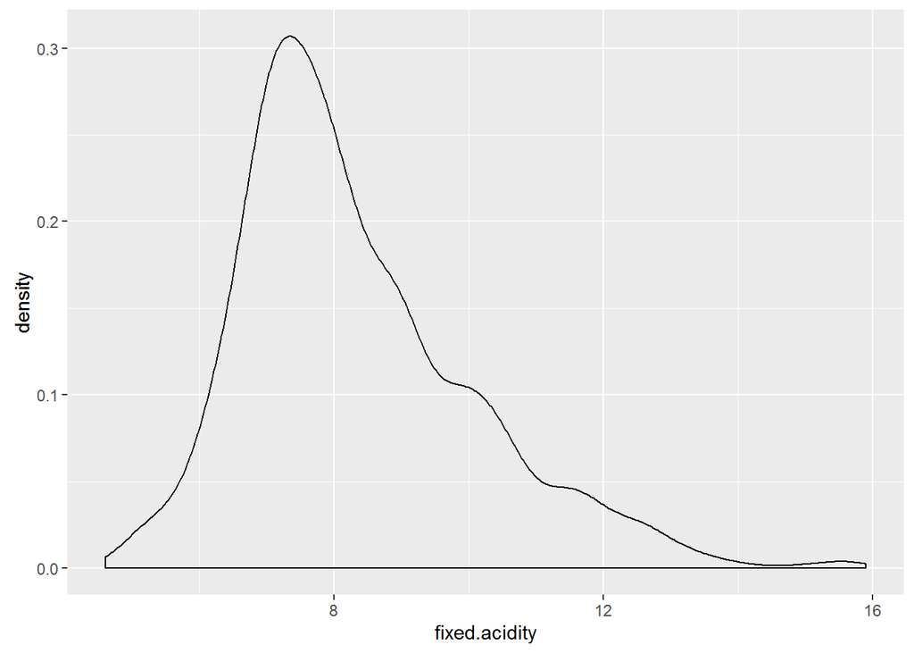

Fixed acidity contains most acids involved with wine or fixed or nonvolatile that do not evaporate readily. It is slightly positively skewed and has a mean of 8.3.

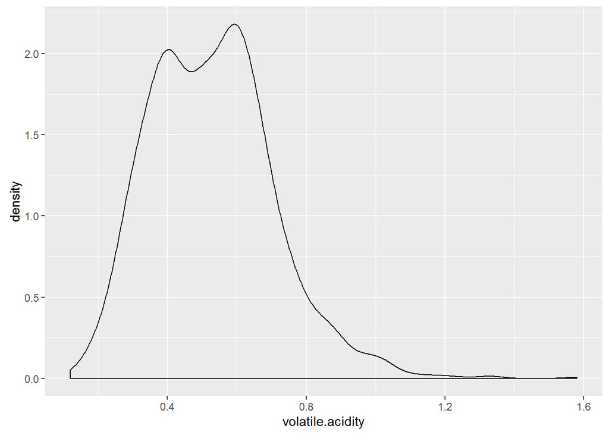

Volatile acidity is the amount of acetic acid in wine, which at too high of levels can lead to an unpleasant, vinegar taste. It is slightly positively skewed and has a mean of 0.53.

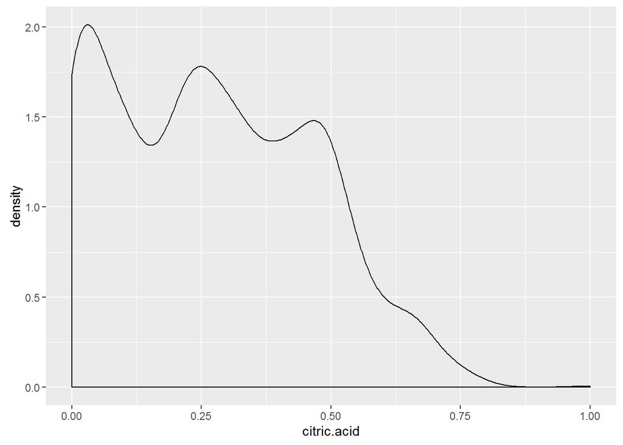

Citric acid is found in small quantities, citric acid can add ‘freshness’ and flavor to wines. Citric acid has a mean of 0.27 and is positively skewed.

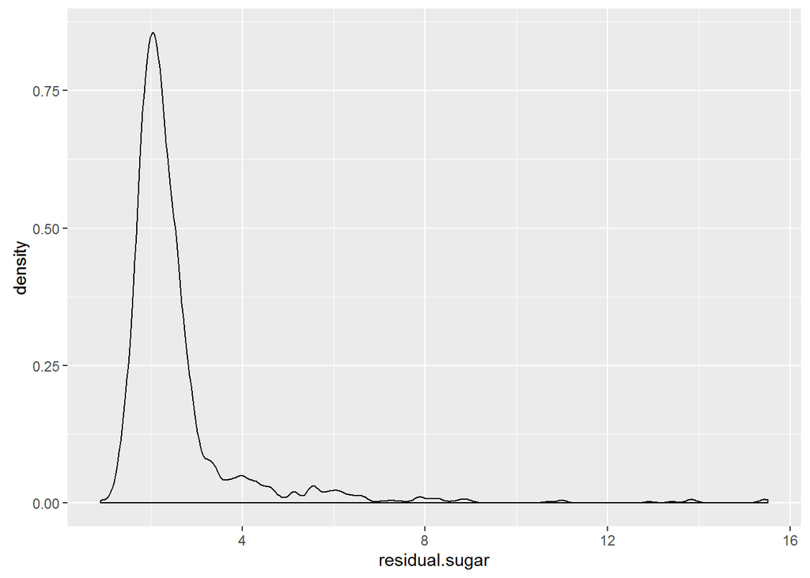

Residual sugar is the amount of sugar remaining after fermentation stops, it’s rare to find wines with less than 1 gram/liter and wines with greater than 45 grams/liter are considered sweet. Residual sugar has a mean of 2.5 and is positively skewed.

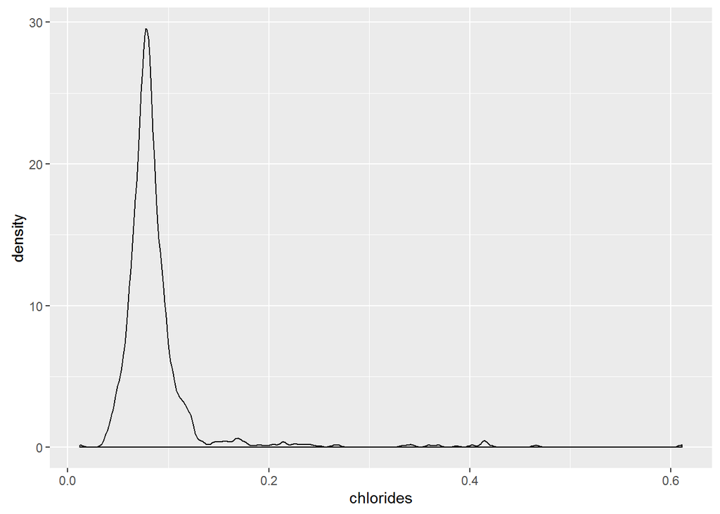

Chlorides is the amount of salt in the wine. Chlorides has a mean of 0.09 and is positively skewed.

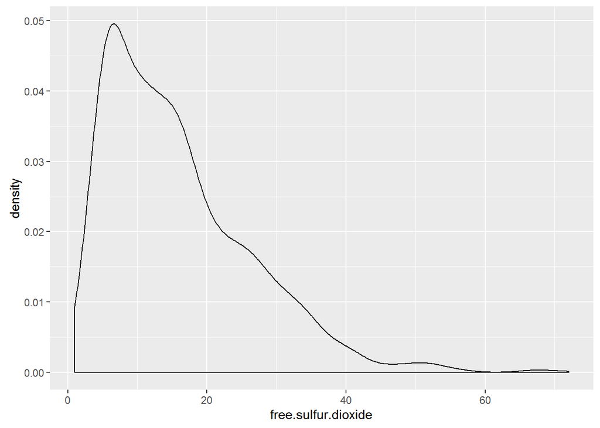

Free sulfur dioxide is the free form of SO2 exists in equilibrium between molecular SO2 (as a dissolved gas) and bisulfite ion; it prevents microbial growth and the oxidation of wine.  
Free sulfur dioxide has a mean of 15.9 and is positively skewed.

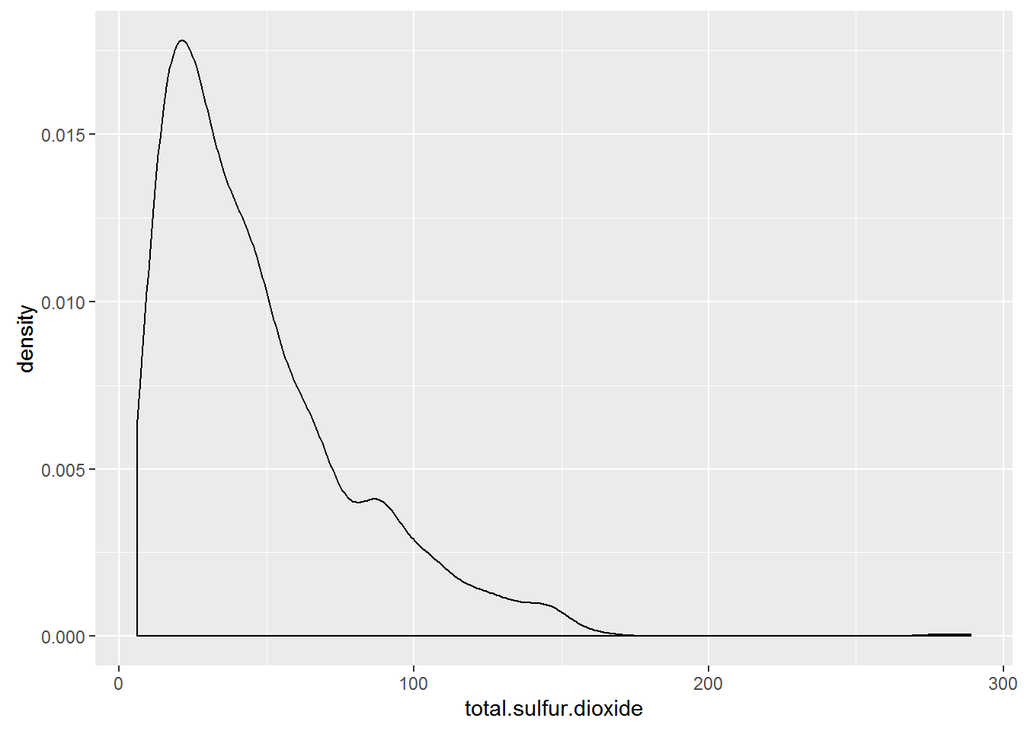

Total sulfur dioxide is the amount of free and bound forms of S02; in low concentrations, SO2 is mostly undetectable in wine, but at free SO2 concentrations over 50 ppm, SO2 becomes evident in the nose and taste of wine. Total sulfur dioxide has a mean of 46.5 and is positively skewed.

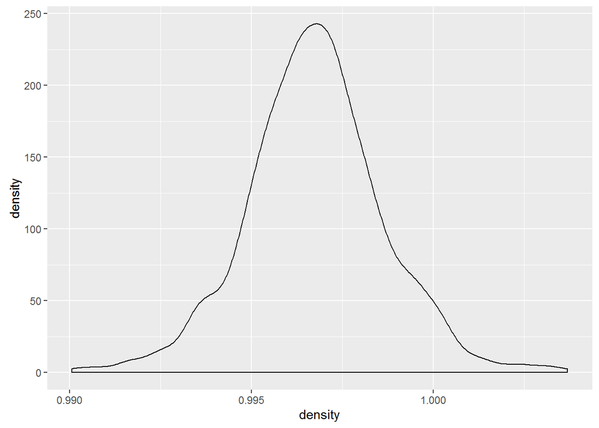

The density of water is close to that of water depending on the percent alcohol and sugar content. Density has a mean of 1 and is normally distributed.

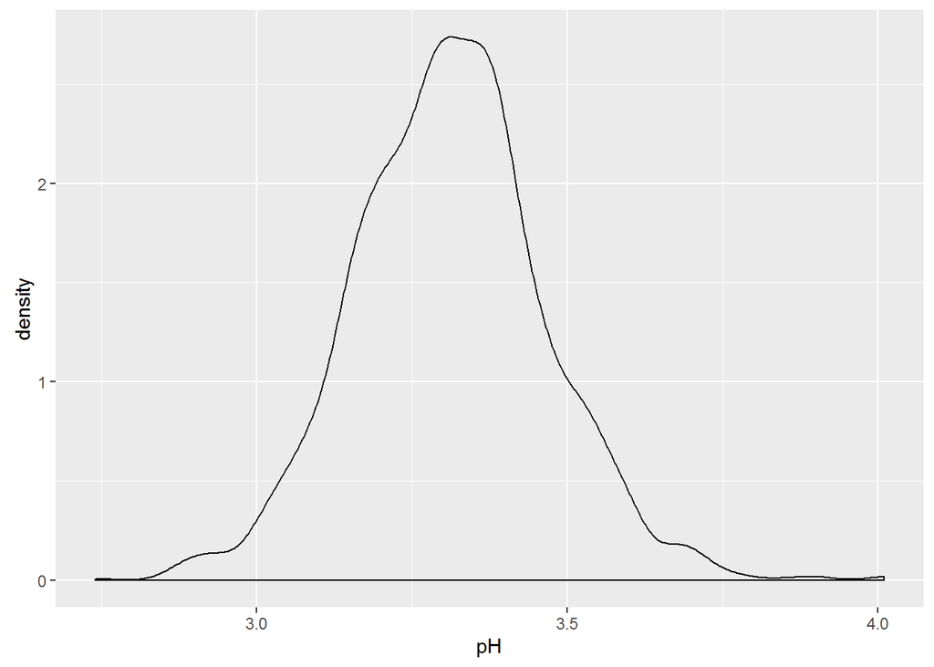

pH describes how acidic or basic a wine is on a scale from 0 (very acidic) to 14 (very basic). pH appears to be normally distributed with a mean of 3.311.

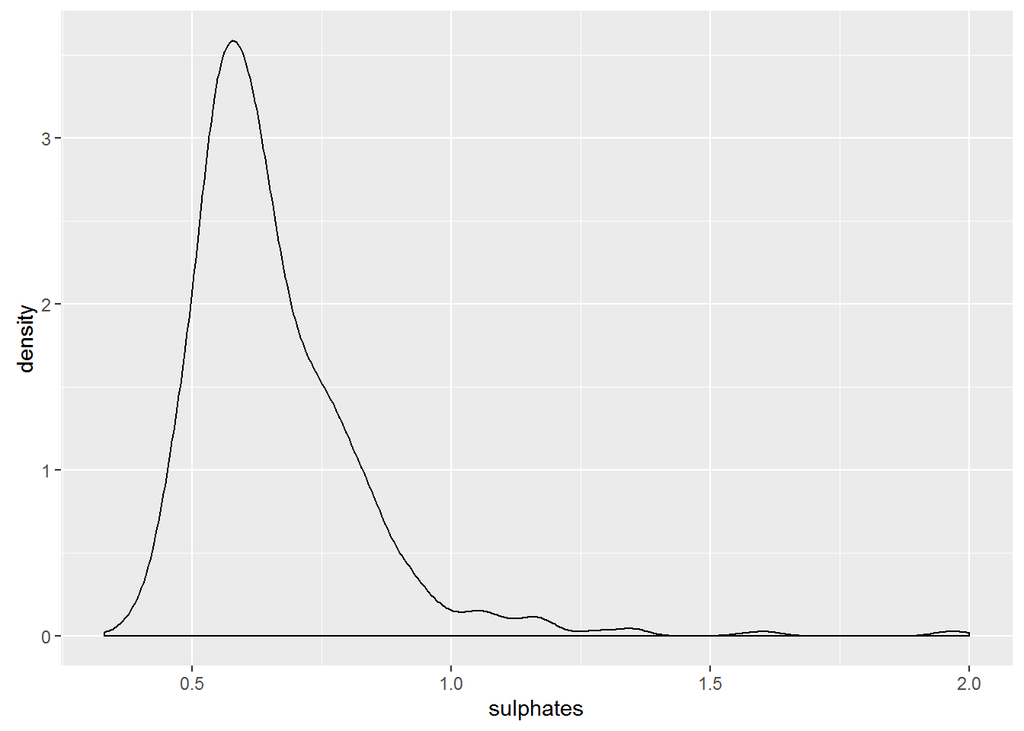

Sulphates is a wine additive which can contribute to sulfur dioxide gas (S02) levels, wich acts as an antimicrobial and antioxidant. It has a mean of 0.7 and is positively skewed.

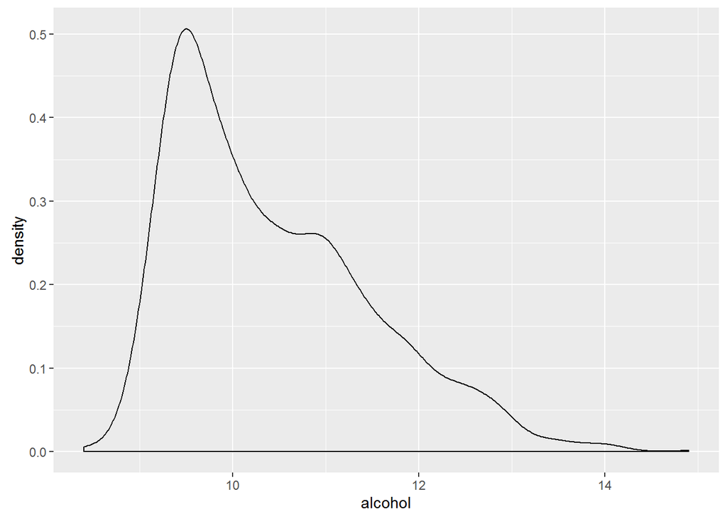

I created histograms for all the features and it looks like several of the variables are positively skewed. I will dig deeper into this once I select the features of interest but it’s good to know this set could benefit from log scaling.

```
##                      fixed.acidity volatile.acidity citric.acid
## fixed.acidity                 1.00            -0.26        0.67
## volatile.acidity             -0.26             1.00       -0.55
## citric.acid                   0.67            -0.55        1.00
## residual.sugar                0.11             0.00        0.14
## chlorides                     0.09             0.06        0.20
## free.sulfur.dioxide          -0.15            -0.01       -0.06
## total.sulfur.dioxide         -0.11             0.08        0.04
## density                       0.67             0.02        0.36
## pH                           -0.68             0.23       -0.54
## sulphates                     0.18            -0.26        0.31
## alcohol                      -0.06            -0.20        0.11
## quality                       0.12            -0.39        0.23
##                      residual.sugar chlorides free.sulfur.dioxide
## fixed.acidity                  0.11      0.09               -0.15
## volatile.acidity               0.00      0.06               -0.01
## citric.acid                    0.14      0.20               -0.06
## residual.sugar                 1.00      0.06                0.19
## chlorides                      0.06      1.00                0.01
## free.sulfur.dioxide            0.19      0.01                1.00
## total.sulfur.dioxide           0.20      0.05                0.67
## density                        0.36      0.20               -0.02
## pH                            -0.09     -0.27                0.07
## sulphates                      0.01      0.37                0.05
## alcohol                        0.04     -0.22               -0.07
## quality                        0.01     -0.13               -0.05
##                      total.sulfur.dioxide density    pH sulphates alcohol
## fixed.acidity                       -0.11    0.67 -0.68      0.18   -0.06
## volatile.acidity                     0.08    0.02  0.23     -0.26   -0.20
## citric.acid                          0.04    0.36 -0.54      0.31    0.11
## residual.sugar                       0.20    0.36 -0.09      0.01    0.04
## chlorides                            0.05    0.20 -0.27      0.37   -0.22
## free.sulfur.dioxide                  0.67   -0.02  0.07      0.05   -0.07
## total.sulfur.dioxide                 1.00    0.07 -0.07      0.04   -0.21
## density                              0.07    1.00 -0.34      0.15   -0.50
## pH                                  -0.07   -0.34  1.00     -0.20    0.21
## sulphates                            0.04    0.15 -0.20      1.00    0.09
## alcohol                             -0.21   -0.50  0.21      0.09    1.00
## quality                             -0.19   -0.17 -0.06      0.25    0.48
##                      quality
## fixed.acidity           0.12
## volatile.acidity       -0.39
## citric.acid             0.23
## residual.sugar          0.01
## chlorides              -0.13
## free.sulfur.dioxide    -0.05
## total.sulfur.dioxide   -0.19
## density                -0.17
## pH                     -0.06
## sulphates               0.25
## alcohol                 0.48
## quality                 1.00
```

### What is/are the main feature(s) of interest in your dataset?

I decided on the following features of interest based on the highest correlation to quality: alcohol, volatile acidity, and sulphates.

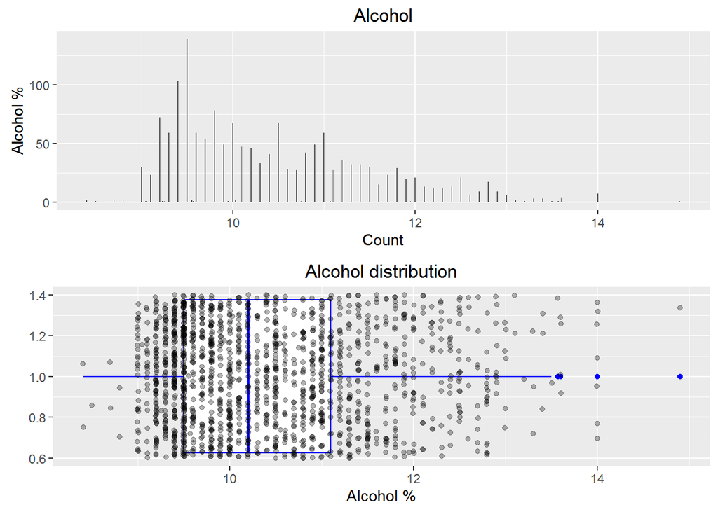

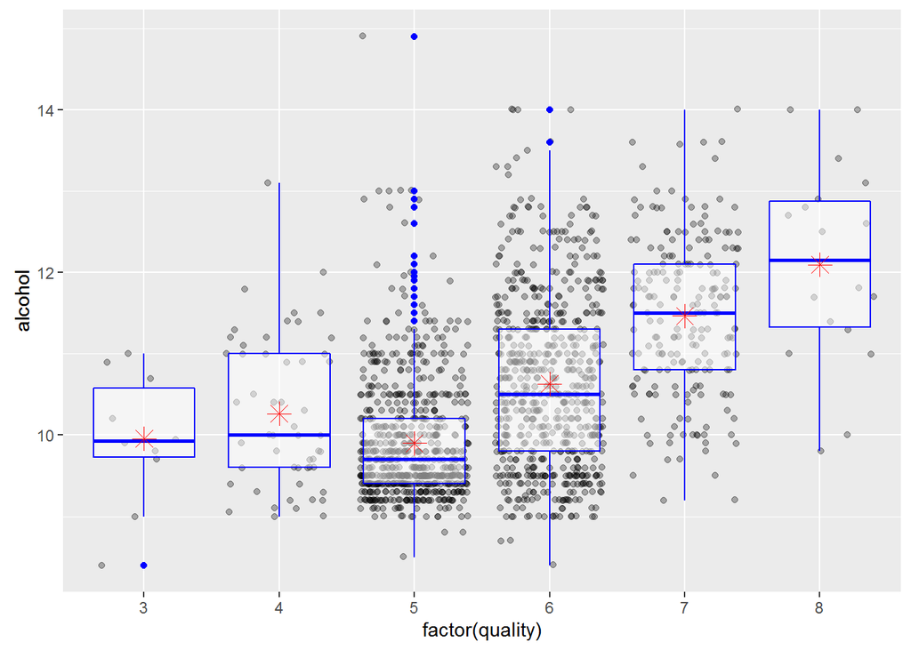

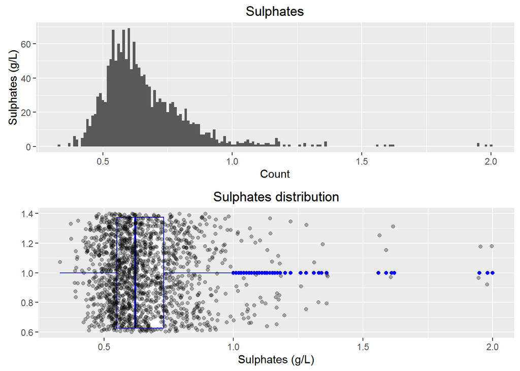

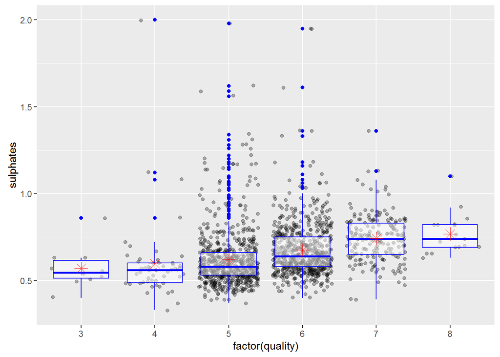

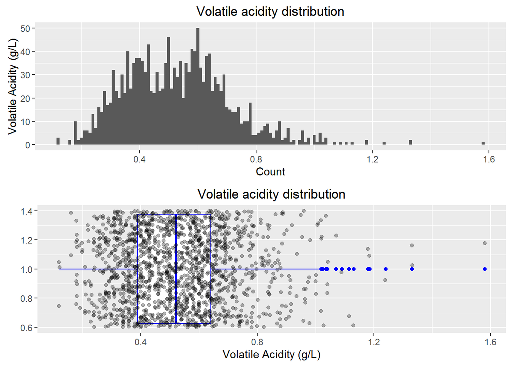

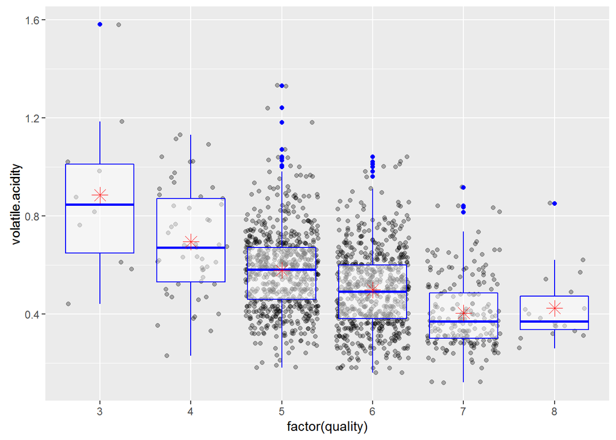

```
## [1] 0.08570932
```

### Did you create any new variables from existing variables in the dataset?

I decided that fixed and voliatile acidity can be combined into total acidity. However, I discovered that total_acidity only had a correlation to quality of 0.085.

```
## [1] 0.8592144
```

```
## [1] 2.424118
```

```
## [1] 0.6703331
```

```
## [1] 0.2173931
```

### Of the features you investigated, were there any unusual distributions? Did you perform any operations on the data to tidy, adjust, or change the form of the data? If so, why did you do this?

All the features that I am interested are positively skewed with sulphates being the most promently skewed. Therefore, I decided to log transform these features and we can see the improved skewness below.

```
## [1] 0.6765268
```

```
## [1] 1.607477
```

```
## [1] 0.2696612
```

```
## [1] -0.2537001
```

We can see the log transform reduced the sknewess across the feature set.

```
## [1] 0.2267344
```

```
## [1] 0.06320049
```

```
## [1] 0.1525354
```

### Talk about some of the relationships you observed in this part of the investigation. Were there features that strengthened each other in terms of looking at your feature(s) of interest?

I chose the variables with the higest correlation to quality: alcohol, volatile.acidity, and sulphates. I ran the R2 for these features against quality and came up with a total R2 of 0.44, which means that 44% of quality can be explained by these variables.  
Sulphates looks particularly low at only 6%.

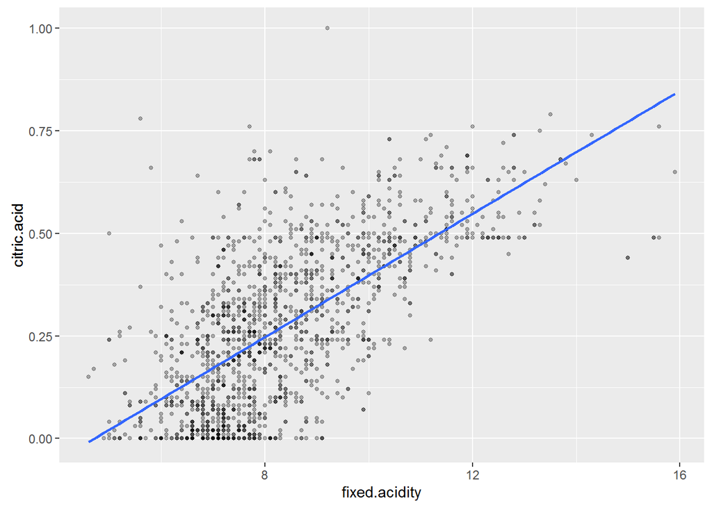

### Did you observe any interesting relationships between the other features (not the main feature(s) of interest)?

I found it interesting that fixed acidity had a correlation of 0.67 to citric acid. There seems to be a lot of features related to acid in the dataset. If I am not able to accurately predict from the three features that I chose, then I will look into engineering another feature around acidity that combines citric acid.

### What was the strongest relationship you found?

The strongest relationship was 0.48 correlation of quality to alcohol.  
I expect that this is the most impactful feature to predict the quality of wine, but we will later test this hypothesis.

### Talk about some of the relationships you observed in this part of the investigation. Were there features that strengthened each other in terms of looking at your feature(s) of interest?

Per the graph below, density has a strong negative correlation to alcohol of (0.5) and a positive correlation of 0.36 to residual sugars.  
This makes sense since the data set description of this feature says that density is dependent on alcohol levels and sugars.  
However, it’s interesting to see the relationship in terms of correlation numbers.

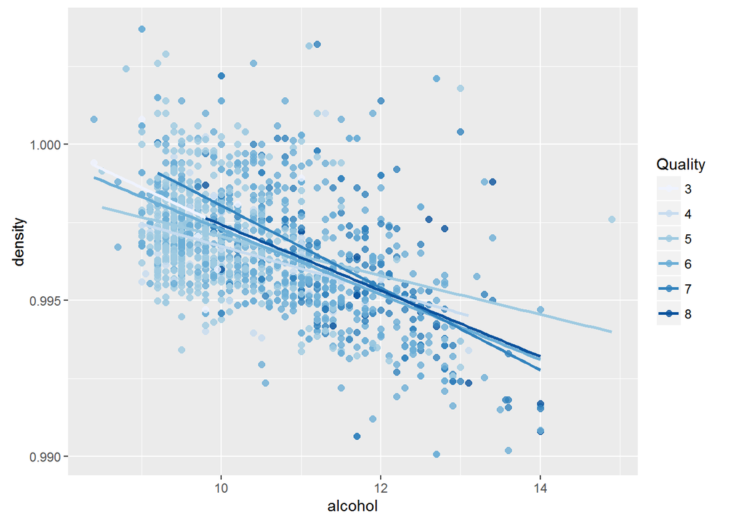

### Were there any interesting or surprising interactions between features?

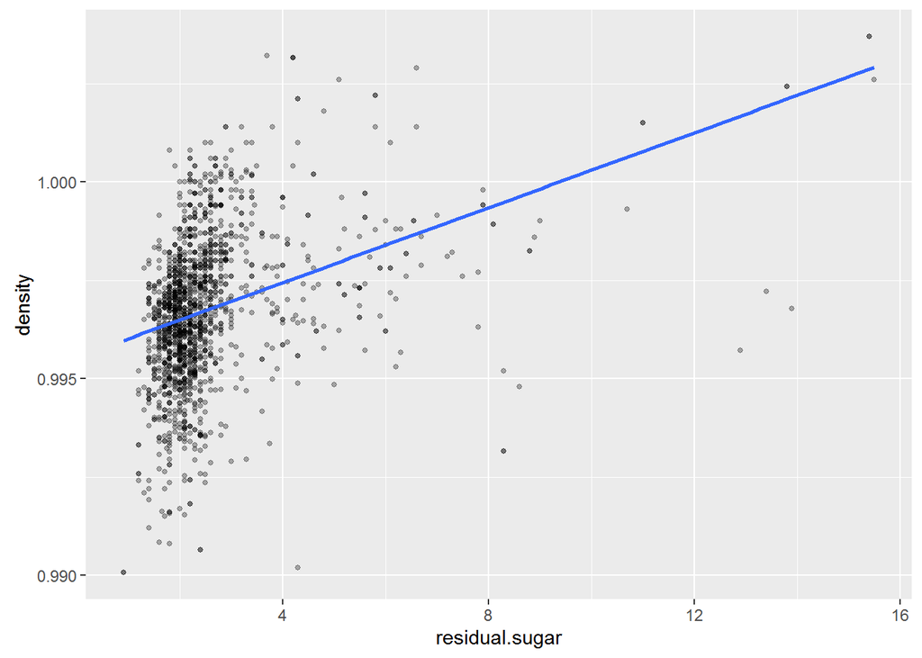

Earlier I could have said that residual sugars is a throw away variable because it has only 0.0137 correlation to quality. However, residual sugar can impact density which can negativitly impact alcohol which can impact wine quality. I wonder if PCA would condense residual sugars, density, and alcohol together. I also believe that removing the outliers from residual sugar would change this chart significantly.

```
##
## Call:
##  randomForest(formula = factor(quality_log) ~ volatile.acidity_log +      alcohol_log + sulphates_log, data = train, metric = "Accuracy")
##                Type of random forest: classification
##                      Number of trees: 500
## No. of variables tried at each split: 1
##
##         OOB estimate of  error rate: 34.94%
## Confusion matrix:
##                   0.602059991327962 0.698970004336019 0.778151250383644
## 0.602059991327962                 0                 0                 7
## 0.698970004336019                 0                 2                18
## 0.778151250383644                 0                 2               369
## 0.845098040014257                 0                 2               112
## 0.903089986991944                 0                 0                 9
## 0.954242509439325                 0                 0                 1
##                   0.845098040014257 0.903089986991944 0.954242509439325
## 0.602059991327962                 2                 0                 0
## 0.698970004336019                12                 0                 0
## 0.778151250383644               106                 5                 0
## 0.845098040014257               297                36                 3
## 0.903089986991944                62                59                 2
## 0.954242509439325                 6                 6                 1
##                   class.error
## 0.602059991327962   1.0000000
## 0.698970004336019   0.9375000
## 0.778151250383644   0.2344398
## 0.845098040014257   0.3400000
## 0.903089986991944   0.5530303
## 0.954242509439325   0.9285714
```

### OPTIONAL: Did you create any models with your dataset? Discuss the strengths and limitations of your model.

I chose the random forest (RF) to evaluate the dataset.

Strengths of RF: + Limited parameter tuning … default parameters often have great performance + Fast + Versitile + Great for feature selection because it evaluates a lot of decision tree variations + Illustrates information gain by inclusion/exclusion of variables in the forest

Limitations of RF: + Poor Peformance: small data sets + Fragmentation Problem: each split has diminishing information gain + Prone to overfitting

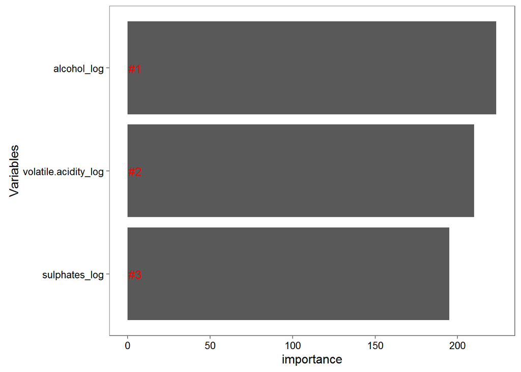

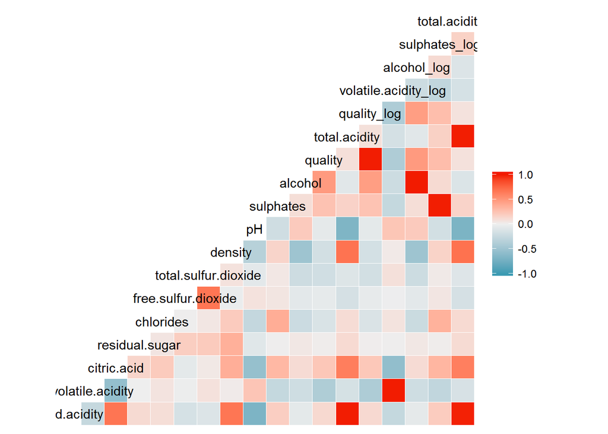

The random forest classifier is a powerful tool to predict the quality of wine.

It’s good to see this classifier confirms that alcohol (the feature with the highest correlation) is indeed the most important for predicting quality.

The correlation map is a great visual to show why we initially chose alcohol, volatile.acidity, and sulphates as the main features to explore.  
It also highlights the relationships we observed between other features such as density and residual sugars and alcohol. I would use this to further explore additional features to test in the decision tree.

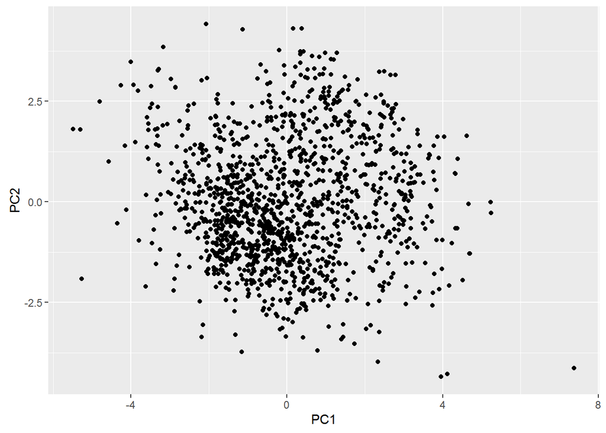

# Final Plots and Summary

### Plot One

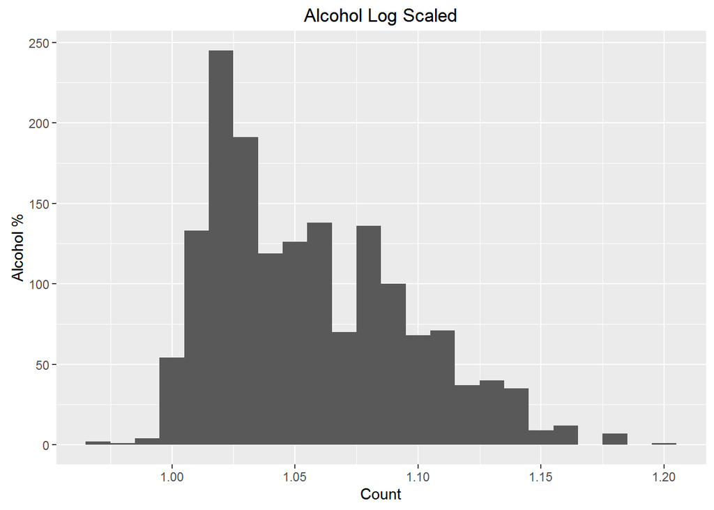

### Description One

This graph is a great illustration that shows the impact of feature scaling alcohol. The initial histogram of alcohol was very spread out and difficult to read, but log transforming the data gives us a much cleaner look at this feature.

### Plot Two

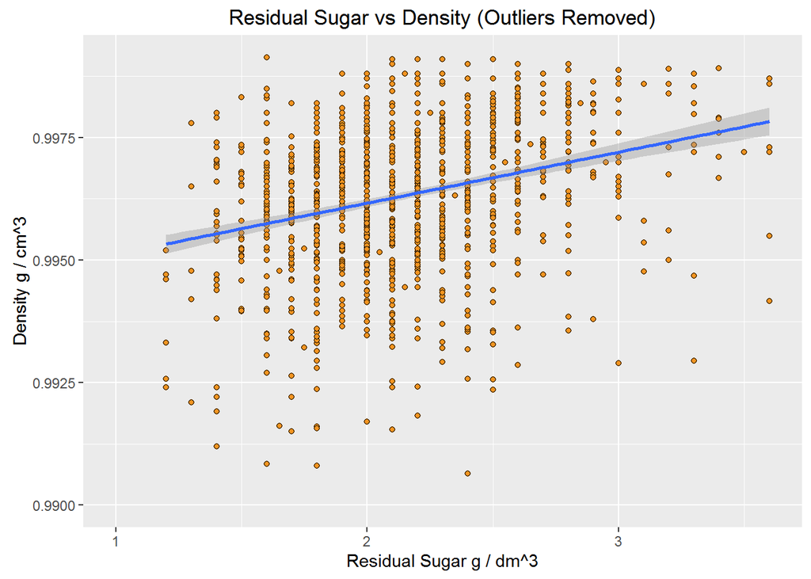

### Description Two

I chose the graph above because I wanted to further investigate the relationship between residual sugars and density. There does still appear to be a direct linear relationship between these variables even after removing outliers.

### Plot Three

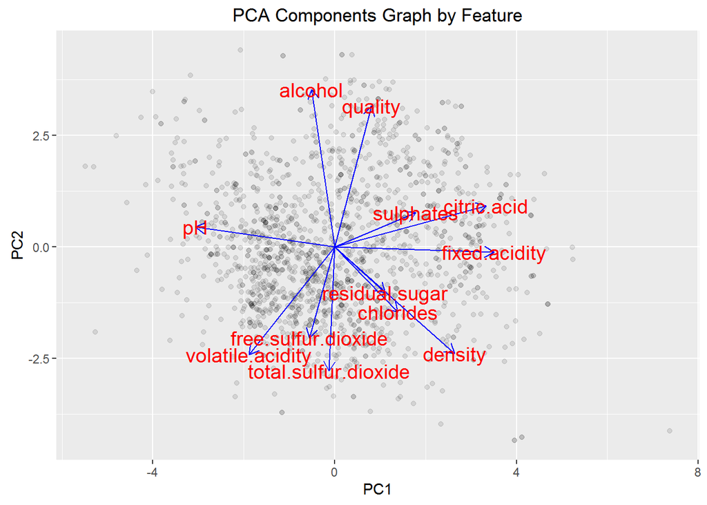

### Description Three

I added the feature names to my PCA graph and found there were 4 components. I found it fascinating that alcohol, sulphates and volatile acidity all belonged to seperate components. This makes me believe that these features selected are fairly balanced. However, PH belongs to a seperate component and perhaps adding this feature would have increased the performance of the classifier.

# Reflection

Overall, I am happy to have successfully built a base level starting point upon which more indepth analysis can be performed.